# Caso CPS: ¿Qué Impulsa los Ingresos?

### 5.5 Gradient Boosting — el benchmark de rendimiento

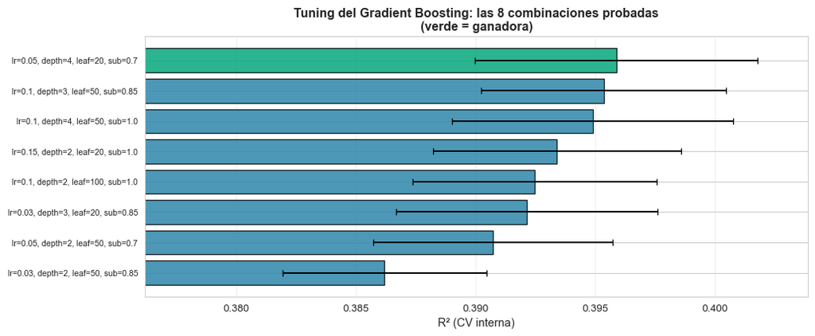

```
Mejores hiperparámetros: {'subsample': 0.7, 'min_samples_leaf': 20, 'max_depth': 4, 'learning_rate': 0.05}
R² CV interna (de la búsqueda): 0.3959
R² in-sample (todos los datos): 0.4136
→ La evaluación HONESTA (validación cruzada anidada) está en la sección 6.
```

```python
from sklearn.ensemble import GradientBoostingRegressor

# Espacio de búsqueda. learning_rate y max_depth controlan la complejidad;
# subsample < 1 introduce aleatoriedad que regulariza (stochastic gradient boosting).
gb_dist = {
    'learning_rate':    [0.03, 0.05, 0.1, 0.15],
    'max_depth':        [2, 3, 4],
    'min_samples_leaf': [20, 50, 100],
    'subsample':        [0.7, 0.85, 1.0],
}

# RandomizedSearchCV muestrea 8 combinaciones, cada una evaluada con la CV interna.
gb_search = RandomizedSearchCV(
    GradientBoostingRegressor(n_estimators=300, random_state=RANDOM_STATE),
    gb_dist, n_iter=8, cv=inner_cv, scoring='r2',
    random_state=RANDOM_STATE, n_jobs=-1
)
gb_search.fit(X, y)
gb = gb_search.best_estimator_   # mejor modelo, ya reajustado sobre todos los datos

# Visualizar las combinaciones probadas, ordenadas por R² CV
gb_res = pd.DataFrame(gb_search.cv_results_).sort_values('mean_test_score')
labels = [f"lr={p['learning_rate']}, depth={p['max_depth']}, leaf={p['min_samples_leaf']}, sub={p['subsample']}"
          for p in gb_res['params']]
fig, ax = plt.subplots(figsize=(11, 4.6))
colors = [PALETTE['success'] if s == gb_res['mean_test_score'].max() else PALETTE['primary']
          for s in gb_res['mean_test_score']]
ax.barh(range(len(gb_res)), gb_res['mean_test_score'], xerr=gb_res['std_test_score'],
        capsize=3, color=colors, edgecolor='black', alpha=0.85)
ax.set_yticks(range(len(gb_res)))
ax.set_yticklabels(labels, fontsize=8)
ax.set_xlabel('R² (CV interna)')
ax.set_title('Tuning del Gradient Boosting: las 8 combinaciones probadas\n(verde = ganadora)',
             fontweight='bold')
ax.set_xlim(gb_res['mean_test_score'].min() - 0.01, gb_res['mean_test_score'].max() + 0.008)
ax.grid(True, alpha=0.3, axis='x')
plt.tight_layout()
plt.show()

print(f"Mejores hiperparámetros: {gb_search.best_params_}")
print(f"R² CV interna (de la búsqueda): {gb_search.best_score_:.4f}")
print(f"R² in-sample (todos los datos): {gb.score(X, y):.4f}")
print("→ La evaluación HONESTA (validación cruzada anidada) está en la sección 6.")
```

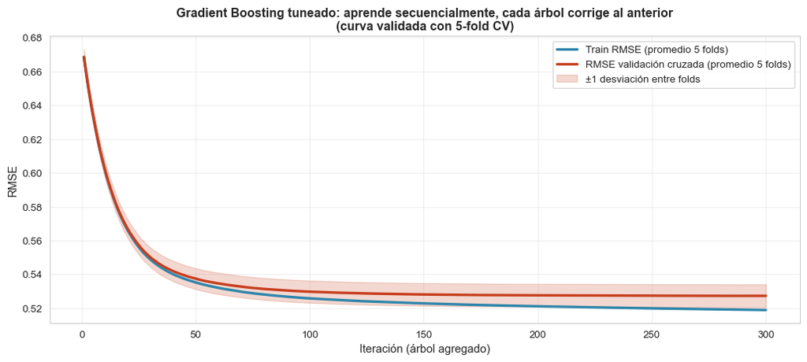

```python
# Curva de aprendizaje de Gradient Boosting con validación cruzada:
# en cada uno de los 5 folds medimos el RMSE iteración por iteración.
# Usamos los hiperparámetros YA TUNEADOS (gb_search.best_params_).
from sklearn.metrics import mean_squared_error

n_est = gb.n_estimators
cv_staged = np.zeros((N_SPLITS, n_est))
train_staged = np.zeros((N_SPLITS, n_est))

for k, (tr_idx, te_idx) in enumerate(cv.split(X)):
    g = GradientBoostingRegressor(n_estimators=n_est, random_state=RANDOM_STATE,
                                  **gb_search.best_params_)
    g.fit(X.iloc[tr_idx], y.iloc[tr_idx])
    for i, y_pred in enumerate(g.staged_predict(X.iloc[te_idx])):
        cv_staged[k, i] = np.sqrt(mean_squared_error(y.iloc[te_idx], y_pred))
    for i, y_pred in enumerate(g.staged_predict(X.iloc[tr_idx])):
        train_staged[k, i] = np.sqrt(mean_squared_error(y.iloc[tr_idx], y_pred))

stages = np.arange(1, n_est + 1)
cv_mean, cv_std = cv_staged.mean(axis=0), cv_staged.std(axis=0)
train_mean = train_staged.mean(axis=0)

fig, ax = plt.subplots(figsize=(11, 5))
ax.plot(stages, train_mean, linewidth=2.5, label='Train RMSE (promedio 5 folds)', color=PALETTE['primary'])
ax.plot(stages, cv_mean, linewidth=2.5, label='RMSE validación cruzada (promedio 5 folds)', color=PALETTE['danger'])
ax.fill_between(stages, cv_mean - cv_std, cv_mean + cv_std, color=PALETTE['danger'], alpha=0.2,
                label='±1 desviación entre folds')
ax.set_xlabel('Iteración (árbol agregado)')
ax.set_ylabel('RMSE')
ax.set_title('Gradient Boosting tuneado: aprende secuencialmente, cada árbol corrige al anterior\n(curva validada con 5-fold CV)',
             fontweight='bold')
ax.legend()
ax.grid(True, alpha=0.3)
plt.tight_layout()
plt.show()
```

## 6. Evaluación comparativa visual

Comparamos los 5 modelos desde múltiples ángulos. El desempeño se mide con **validación cruzada anidada** (ver 5.0): cada modelo se tunea y se evalúa de forma que el fold de prueba nunca influyó en sus hiperparámetros — un estimado **honesto**, sin el optimismo del tuning.

> ⏱️ La siguiente celda corre la validación cruzada anidada: entrena cientos de modelos y **puede tardar varios minutos**.

```python
# Evaluación HONESTA por VALIDACIÓN CRUZADA ANIDADA (nested CV)
#   Loop EXTERNO (cv, 5 folds)        -> mide el desempeño
#   Loop INTERNO (inner_cv, en cada búsqueda) -> elige los hiperparámetros
# Como el tuning de cada fold externo NO ve su fold de validación, el R² resultante
# es un estimado insesgado: no premia el haber tuneado contra esos mismos datos.
from sklearn.metrics import mean_squared_error, mean_absolute_error, r2_score

# Cada modelo se representa por su PROCEDIMIENTO completo (con búsqueda incluida).
# El preprocesamiento va dentro de Pipeline -> el scaler se ajusta solo con train.
cv_models = {
    'OLS':   LinearRegression(),
    'Lasso': make_pipeline(StandardScaler(),
                           LassoCV(cv=inner_cv, random_state=RANDOM_STATE, max_iter=5000)),
    'Árbol': GridSearchCV(DecisionTreeRegressor(random_state=RANDOM_STATE),
                          tree_grid, cv=inner_cv, scoring='r2', n_jobs=-1),
    'Random Forest': RandomizedSearchCV(
        RandomForestRegressor(n_estimators=300, n_jobs=-1, random_state=RANDOM_STATE),
        rf_dist, n_iter=10, cv=inner_cv, scoring='r2',
        random_state=RANDOM_STATE, n_jobs=-1),
    'Gradient Boosting': RandomizedSearchCV(
        GradientBoostingRegressor(n_estimators=300, random_state=RANDOM_STATE),
        gb_dist, n_iter=8, cv=inner_cv, scoring='r2',
        random_state=RANDOM_STATE, n_jobs=-1),
}

print('Corriendo validación cruzada anidada (puede tardar varios minutos)...')
evals = []
for name, model in cv_models.items():
    oof_pred = np.zeros(len(y))                       # predicción out-of-fold de cada obs.
    r2_tr, r2_te, rmse_te, mae_te = [], [], [], []
    for tr_idx, te_idx in cv.split(X):
        m = clone(model)
        m.fit(X.iloc[tr_idx], y.iloc[tr_idx])         # esto incluye la búsqueda interna
        p_te = m.predict(X.iloc[te_idx])
        p_tr = m.predict(X.iloc[tr_idx])
        oof_pred[te_idx] = p_te
        r2_tr.append(r2_score(y.iloc[tr_idx], p_tr))
        r2_te.append(r2_score(y.iloc[te_idx], p_te))
        rmse_te.append(np.sqrt(mean_squared_error(y.iloc[te_idx], p_te)))
        mae_te.append(mean_absolute_error(y.iloc[te_idx], p_te))
    evals.append({
        'Modelo':      name,
        'R² train':    np.mean(r2_tr),
        'R² CV':       np.mean(r2_te),
        'R² CV std':   np.std(r2_te),
        'RMSE CV':     np.mean(rmse_te),
        'RMSE CV std': np.std(rmse_te),
        'MAE CV':      np.mean(mae_te),
        'pred_cv':     oof_pred,
    })
    print(f"  ✓ {name:18s} R² nested CV = {np.mean(r2_te):.4f} ± {np.std(r2_te):.4f}")

results_df = pd.DataFrame([{k: v for k, v in e.items() if k != 'pred_cv'} for e in evals])
results_df['Error % aprox'] = (np.exp(results_df['MAE CV']) - 1) * 100
results_df.round(4)
```

```
Corriendo validación cruzada anidada (puede tardar varios minutos)...
  ✓ OLS                R² nested CV = 0.3668 ± 0.0097
  ✓ Lasso              R² nested CV = 0.3667 ± 0.0097
  ✓ Árbol              R² nested CV = 0.3703 ± 0.0109
  ✓ Random Forest      R² nested CV = 0.3901 ± 0.0116
  ✓ Gradient Boosting  R² nested CV = 0.3967 ± 0.0110
```

|  | Modelo | R² train | R² CV | R² CV std | RMSE CV | RMSE CV std | MAE CV | Error % aprox |
| --- | --- | --- | --- | --- | --- | --- | --- | --- |
| 0 | OLS | 0.3674 | 0.3668 | 0.0097 | 0.5403 | 0.0060 | 0.3957 | 48.5455 |
| 1 | Lasso | 0.3674 | 0.3667 | 0.0097 | 0.5403 | 0.0060 | 0.3957 | 48.5403 |
| 2 | Árbol | 0.3855 | 0.3703 | 0.0109 | 0.5387 | 0.0067 | 0.3953 | 48.4823 |
| 3 | Random Forest | 0.4431 | 0.3901 | 0.0116 | 0.5302 | 0.0071 | 0.3876 | 47.3368 |
| 4 | Gradient Boosting | 0.4149 | 0.3967 | 0.0110 | 0.5273 | 0.0068 | 0.3850 | 46.9642 |

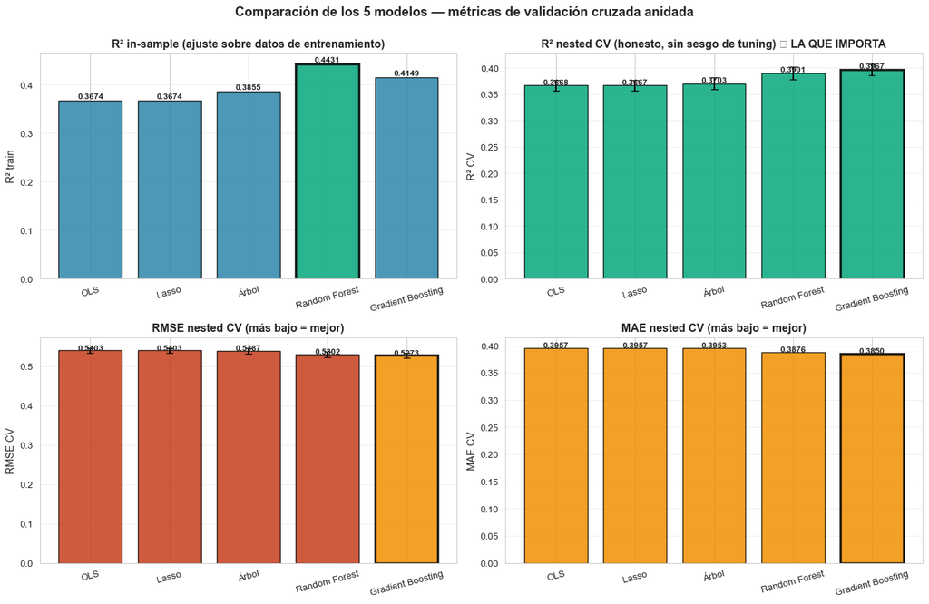

```python
# Comparación visual de las métricas de validación cruzada anidada — un panel grande
fig, axes = plt.subplots(2, 2, figsize=(14, 9))
fig.suptitle('Comparación de los 5 modelos — métricas de validación cruzada anidada',
             fontsize=14, fontweight='bold', y=1.00)

metrics_to_plot = [
    ('R² train', 'R² in-sample (ajuste sobre datos de entrenamiento)',     PALETTE['primary'], True,  None),
    ('R² CV',    'R² nested CV (honesto, sin sesgo de tuning) ⭐ LA QUE IMPORTA', PALETTE['success'], True,  'R² CV std'),
    ('RMSE CV',  'RMSE nested CV (más bajo = mejor)',                       PALETTE['danger'],  False, 'RMSE CV std'),
    ('MAE CV',   'MAE nested CV (más bajo = mejor)',                        PALETTE['warning'], False, None),
]

for ax, (metric, title, color, higher_better, err_col) in zip(axes.flat, metrics_to_plot):
    vals = results_df[metric].values
    errs = results_df[err_col].values if err_col else None
    bars = ax.bar(results_df['Modelo'], vals, yerr=errs, capsize=4,
                  color=color, edgecolor='black', alpha=0.85)

    # Resaltar el mejor
    best_idx = vals.argmax() if higher_better else vals.argmin()
    bars[best_idx].set_color(PALETTE['success'] if higher_better else PALETTE['warning'])
    bars[best_idx].set_edgecolor('black')
    bars[best_idx].set_linewidth(2.5)

    # Etiquetas con valores
    span = vals.max() - vals.min() if vals.max() != vals.min() else (vals.max() or 1)
    for bar, val in zip(bars, vals):
        ax.text(bar.get_x() + bar.get_width()/2, bar.get_height() + span*0.05,
                f'{val:.4f}', ha='center', fontsize=9, fontweight='bold')

    ax.set_title(title, fontweight='bold')
    ax.set_ylabel(metric)
    ax.tick_params(axis='x', rotation=15)
    ax.grid(True, alpha=0.3, axis='y')

plt.tight_layout()
plt.show()
```

**Lectura clave:**

- Los modelos lineales (OLS, Lasso) están cerca de los de árbol → las relaciones son **mayormente lineales**. Esto justifica interpretar coeficientes con confianza.
- Random Forest y Gradient Boosting, **ya tuneados**, tienen R² algo superiores → capturan algo de no-linealidad e interacciones, pero la mejora sobre OLS sigue siendo modesta.
- Estos R² provienen de **validación cruzada anidada**: el estimado honesto, sin el optimismo de haber elegido los hiperparámetros que mejor lucían en CV.
- **R² ~0.33-0.42 es normal** en datos socioeconómicos: gran parte de la varianza en ingresos depende de factores no observados (habilidad, industria específica, suerte).

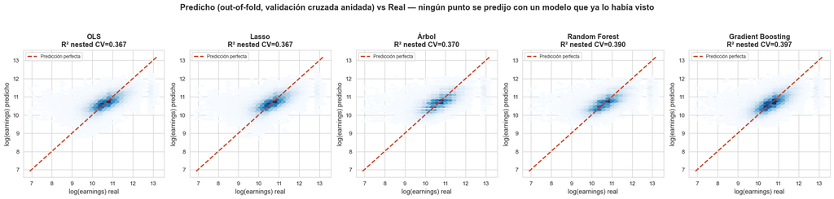

```python
# Predicho (out-of-fold) vs real — el plot más informativo de regresión, para los 5 modelos
fig, axes = plt.subplots(1, 5, figsize=(20, 4.5))

y_arr = y.values
y_min, y_max = y_arr.min(), y_arr.max()

for ax, ev in zip(axes, evals):
    pred = ev['pred_cv']
    # Hexbin para densidad
    hb = ax.hexbin(y_arr, pred, gridsize=30, cmap='Blues', mincnt=1)
    # Línea perfecta
    ax.plot([y_min, y_max], [y_min, y_max], color=PALETTE['danger'], linestyle='--',
            linewidth=2, label='Predicción perfecta')
    ax.set_xlabel('log(earnings) real')
    ax.set_ylabel('log(earnings) predicho')
    ax.set_title(f"{ev['Modelo']}\nR² nested CV={ev['R² CV']:.3f}", fontweight='bold')
    ax.legend(loc='upper left', fontsize=8)

plt.suptitle('Predicho (out-of-fold, validación cruzada anidada) vs Real — ningún punto se predijo con un modelo que ya lo había visto',
             fontsize=14, fontweight='bold', y=1.05)
plt.tight_layout()
plt.show()
```

**Cómo leer esto:** cada modelo se mide contra la línea roja diagonal (predicción perfecta). Las predicciones son **out-of-fold de la validación cruzada anidada**: cada observación se predijo con un modelo entrenado y tuneado sin haberla visto nunca. Si los puntos forman una nube concentrada alrededor de la diagonal → buen ajuste; si están dispersos → mal ajuste. **Los 5 modelos pintan distribuciones similares**, confirmando que las relaciones son mayormente lineales en este problema.

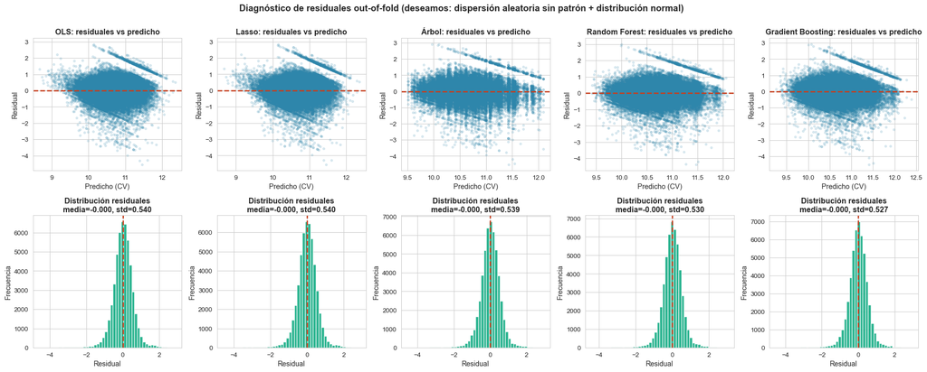

```python
# Análisis de residuales (out-of-fold) — diagnóstico clave de regresión
fig, axes = plt.subplots(2, 5, figsize=(20, 8))

y_arr = y.values
for col, ev in enumerate(evals):
    residuals = y_arr - ev['pred_cv']

    # Panel arriba: residuales vs predicho
    axes[0, col].scatter(ev['pred_cv'], residuals, alpha=0.15, s=10, color=PALETTE['primary'])
    axes[0, col].axhline(0, color=PALETTE['danger'], linestyle='--', linewidth=2)
    axes[0, col].set_xlabel('Predicho (CV)')
    axes[0, col].set_ylabel('Residual')
    axes[0, col].set_title(f"{ev['Modelo']}: residuales vs predicho", fontweight='bold')

    # Panel abajo: histograma de residuales
    axes[1, col].hist(residuals, bins=50, color=PALETTE['success'], edgecolor='white', alpha=0.85)
    axes[1, col].axvline(0, color=PALETTE['danger'], linestyle='--', linewidth=2)
    axes[1, col].set_xlabel('Residual')
    axes[1, col].set_ylabel('Frecuencia')
    axes[1, col].set_title(f"Distribución residuales\nmedia={residuals.mean():.3f}, std={residuals.std():.3f}",
                            fontweight='bold')

plt.suptitle('Diagnóstico de residuales out-of-fold (deseamos: dispersión aleatoria sin patrón + distribución normal)',
             fontsize=14, fontweight='bold', y=1.00)
plt.tight_layout()
plt.show()
```

**Qué buscamos en los residuales:**

- **Arriba (residuales vs predicho):** queremos una nube de puntos sin patrones. Si vemos una forma de embudo o curva, el modelo está mal especificado.
- **Abajo (histograma):** queremos una distribución aproximadamente normal centrada en cero. Eso significa que el modelo no está sesgado sistemáticamente.

En este caso los 5 modelos muestran residuales razonablemente bien comportados, sin patrones alarmantes.

### Side-by-side: ¿qué modelo es el mejor para predecir?

El objetivo del caso es **explicar**, pero conviene saber qué modelo tiene más poder *predictivo*. La siguiente comparación pone los 5 modelos —ya tuneados— lado a lado con sus métricas de **validación cruzada anidada**, los ordena por R² y declara un "campeón" predictivo, sin perder de vista el trade-off con la interpretabilidad.

```
Comparación side-by-side (ordenada por R² de validación cruzada anidada):
```

|  | Ranking | Modelo | R² CV | R² CV std | RMSE CV | MAE CV | R² train | Brecha train-CV | Error % aprox |
| --- | --- | --- | --- | --- | --- | --- | --- | --- | --- |
| 0 | 1 | Gradient Boosting | 0.3967 | 0.0110 | 0.5273 | 0.3850 | 0.4149 | 0.0181 | 46.9642 |
| 1 | 2 | Random Forest | 0.3901 | 0.0116 | 0.5302 | 0.3876 | 0.4431 | 0.0530 | 47.3368 |
| 2 | 3 | Árbol | 0.3703 | 0.0109 | 0.5387 | 0.3953 | 0.3855 | 0.0152 | 48.4823 |
| 3 | 4 | OLS | 0.3668 | 0.0097 | 0.5403 | 0.3957 | 0.3674 | 0.0007 | 48.5455 |
| 4 | 5 | Lasso | 0.3667 | 0.0097 | 0.5403 | 0.3957 | 0.3674 | 0.0007 | 48.5403 |

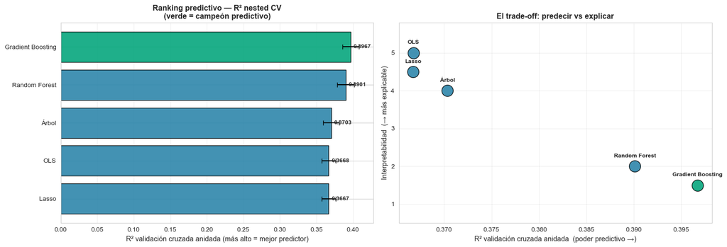

```
🏆 Mejor PREDICTOR (R² nested CV más alto): Gradient Boosting  -> R² = 0.3967 ± 0.0110
   Mejor modelo LINEAL (OLS): R² = 0.3668
   Diferencia: 0.0300 de R² (7.6% relativo).

   📌 Para ESTE caso buscamos EXPLICAR, no predecir: OLS sacrifica
   muy poco R² y a cambio entrega coeficientes con signo, magnitud y p-value.
   Gradient Boosting gana en predicción pura, pero es una 'caja negra' que
   necesita SHAP/PDP para interpretarse.
```

```python
# Side-by-side: ranking de modelos por capacidad predictiva (validación cruzada anidada)
from IPython.display import display

ranking = results_df.sort_values('R² CV', ascending=False).reset_index(drop=True)
ranking.insert(0, 'Ranking', ranking.index + 1)
ranking['Brecha train-CV'] = ranking['R² train'] - ranking['R² CV']   # mide sobreajuste

side_by_side = ranking[['Ranking', 'Modelo', 'R² CV', 'R² CV std', 'RMSE CV',
                        'MAE CV', 'R² train', 'Brecha train-CV', 'Error % aprox']]
print('Comparación side-by-side (ordenada por R² de validación cruzada anidada):')
display(side_by_side.round(4))

champion = ranking.iloc[0]

# Score subjetivo de interpretabilidad (para ilustrar el trade-off predicción <-> explicación)
interpretabilidad = {'OLS': 5.0, 'Lasso': 4.5, 'Árbol': 4.0,
                     'Random Forest': 2.0, 'Gradient Boosting': 1.5}

fig, axes = plt.subplots(1, 2, figsize=(16, 5.5))

# Panel 1: ranking por R² nested CV (mejor arriba) con barras de error
r = ranking.iloc[::-1]
colors = [PALETTE['success'] if m == champion['Modelo'] else PALETTE['primary'] for m in r['Modelo']]
axes[0].barh(r['Modelo'], r['R² CV'], xerr=r['R² CV std'], capsize=4,
             color=colors, edgecolor='black', alpha=0.9)
for i, v in enumerate(r['R² CV']):
    axes[0].text(v + 0.004, i, f'{v:.4f}', va='center', fontweight='bold', fontsize=9)
axes[0].set_xlabel('R² validación cruzada anidada (más alto = mejor predictor)')
axes[0].set_title('Ranking predictivo — R² nested CV\n(verde = campeón predictivo)', fontweight='bold')
axes[0].grid(True, alpha=0.3, axis='x')

# Panel 2: el trade-off predicción vs interpretabilidad
for _, row in ranking.iterrows():
    es_champ = row['Modelo'] == champion['Modelo']
    axes[1].scatter(row['R² CV'], interpretabilidad[row['Modelo']],
                    s=320, color=PALETTE['success'] if es_champ else PALETTE['primary'],
                    edgecolor='black', zorder=3, alpha=0.9)
    axes[1].annotate(row['Modelo'], (row['R² CV'], interpretabilidad[row['Modelo']]),
                     textcoords='offset points', xytext=(0, 14), ha='center',
                     fontsize=9, fontweight='bold')
axes[1].set_xlabel('R² validación cruzada anidada  (poder predictivo →)')
axes[1].set_ylabel('Interpretabilidad  (→ más explicable)')
axes[1].set_title('El trade-off: predecir vs explicar', fontweight='bold')
axes[1].grid(True, alpha=0.3)
axes[1].set_ylim(0.5, 5.8)

plt.tight_layout()
plt.show()

# Veredicto
mejor_lineal = ranking[ranking['Modelo'].isin(['OLS', 'Lasso'])].iloc[0]
brecha_r2 = champion['R² CV'] - mejor_lineal['R² CV']
print(f"\n🏆 Mejor PREDICTOR (R² nested CV más alto): {champion['Modelo']}  "
      f"-> R² = {champion['R² CV']:.4f} ± {champion['R² CV std']:.4f}")
print(f"   Mejor modelo LINEAL ({mejor_lineal['Modelo']}): R² = {mejor_lineal['R² CV']:.4f}")
print(f"   Diferencia: {brecha_r2:.4f} de R² ({brecha_r2 / champion['R² CV'] * 100:.1f}% relativo).")
print(f"\n   📌 Para ESTE caso buscamos EXPLICAR, no predecir: {mejor_lineal['Modelo']} sacrifica")
print(f"   muy poco R² y a cambio entrega coeficientes con signo, magnitud y p-value.")
print(f"   {champion['Modelo']} gana en predicción pura, pero es una 'caja negra' que")
print(f"   necesita SHAP/PDP para interpretarse.")
```

## 7. Interpretación visual completa

Aquí aplicamos las tres técnicas que pide la nota IPADE: **Feature Importance + PDP + SHAP** (global y local).

### 7.1 Feature Importance — tres perspectivas comparadas

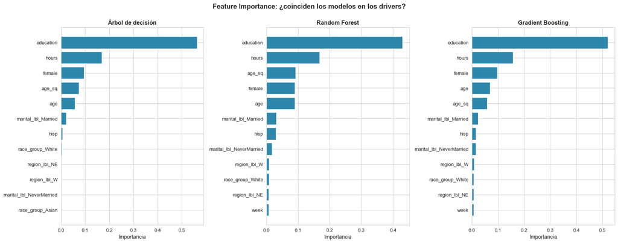

```python
# Comparar FI de tree, RF y GB en un solo panel
fig, axes = plt.subplots(1, 3, figsize=(18, 7))

models_fi = [
    ('Árbol de decisión', tree, axes[0]),
    ('Random Forest', rf, axes[1]),
    ('Gradient Boosting', gb, axes[2]),
]

# Conseguir el top 12 de cada uno
for name, model, ax in models_fi:
    fi = pd.DataFrame({
        'feature': X.columns,
        'importance': model.feature_importances_
    }).sort_values('importance', ascending=False).head(12)
    fi = fi.sort_values('importance', ascending=True)
    ax.barh(fi['feature'], fi['importance'], color=PALETTE['primary'], edgecolor='white')
    ax.set_title(f'{name}', fontweight='bold')
    ax.set_xlabel('Importancia')

plt.suptitle('Feature Importance: ¿coinciden los modelos en los drivers?',
             fontsize=14, fontweight='bold', y=1.00)
plt.tight_layout()
plt.show()
```

**Observación crítica:** los tres modelos coinciden ampliamente en los top 5 drivers. Cuando varios modelos independientes están de acuerdo, las conclusiones son más sólidas.

**Recordatorio IPADE:** importancia mide contribución a la **precisión predictiva**, no causalidad. Que `education` sea #1 no prueba que educar más cause más ingresos.

### 7.2 Partial Dependence Plots — la forma del efecto

Los PDP muestran cómo cambia la predicción al variar **una sola variable**, dejando el resto constante. Detectan umbrales, rendimientos decrecientes y no-linealidades.

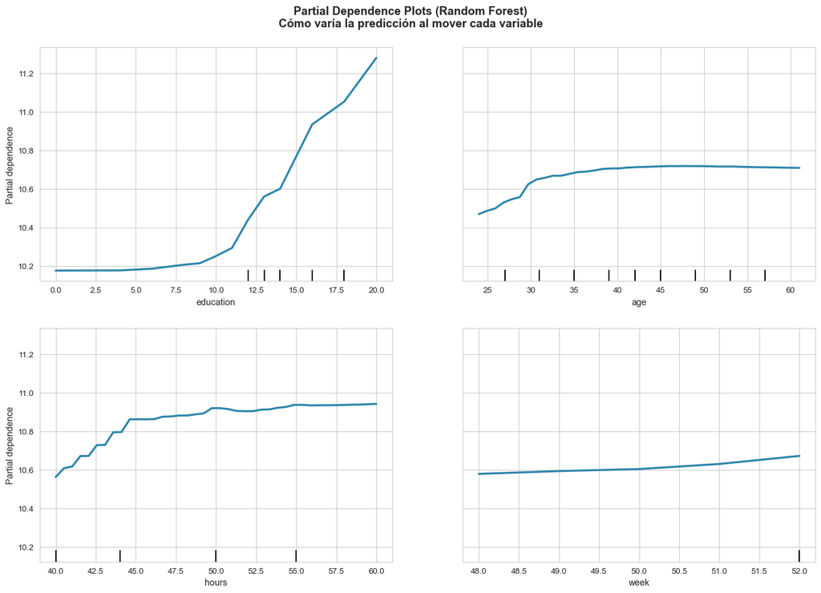

```python
from sklearn.inspection import PartialDependenceDisplay

continuous_features = ['education', 'age', 'hours', 'week']

fig, ax = plt.subplots(figsize=(14, 10))
PartialDependenceDisplay.from_estimator(
    rf, X, continuous_features,
    grid_resolution=40, n_cols=2,
    line_kw={'color': PALETTE['primary'], 'linewidth': 2.5},
    ax=ax
)
plt.suptitle('Partial Dependence Plots (Random Forest)\nCómo varía la predicción al mover cada variable',
             fontsize=14, fontweight='bold', y=1.00)
plt.tight_layout()
plt.show()
```

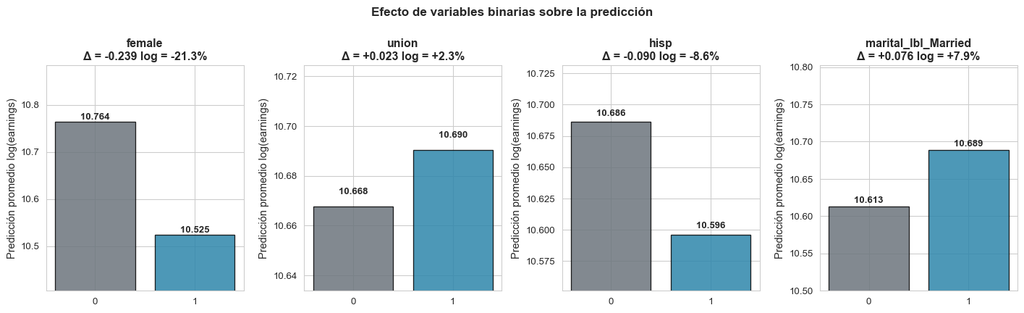

```python
# PDP de variables binarias (categorías) — más fácil leer como barras
binary_to_plot = ['female', 'union', 'hisp']
for col in X.columns:
    if col.startswith('marital_lbl_') and 'Married' in col:
        binary_to_plot.append(col); break

fig, axes = plt.subplots(1, len(binary_to_plot), figsize=(15, 4.5))

for ax, var in zip(axes, binary_to_plot):
    # PDP manual para binarias
    X_temp = X.copy()
    X_temp[var] = 0
    pred_0 = rf.predict(X_temp).mean()
    X_temp[var] = 1
    pred_1 = rf.predict(X_temp).mean()
    diff = pred_1 - pred_0

    bars = ax.bar(['0', '1'], [pred_0, pred_1],
                   color=[PALETTE['neutral'], PALETTE['primary']], edgecolor='black', alpha=0.85)
    ax.set_title(f'{var}\nΔ = {diff:+.3f} log = {(np.exp(diff)-1)*100:+.1f}%',
                 fontweight='bold')
    ax.set_ylabel('Predicción promedio log(earnings)')
    ax.set_ylim(pred_0 - abs(diff)*1.5, pred_1 + abs(diff)*1.5)

    for bar, val in zip(bars, [pred_0, pred_1]):
        ax.text(bar.get_x() + bar.get_width()/2, bar.get_height() + 0.005,
                f'{val:.3f}', ha='center', fontsize=10, fontweight='bold')

plt.suptitle('Efecto de variables binarias sobre la predicción',
             fontsize=13, fontweight='bold', y=1.00)
plt.tight_layout()
plt.show()
```

### 7.3 SHAP — explicaciones globales Y locales

SHAP es lo más avanzado en explicabilidad. Cada predicción se descompone en contribuciones por variable.

```python
try:
    import shap
except ModuleNotFoundError:
    import sys
    import subprocess

    subprocess.check_call([sys.executable, "-m", "pip", "install", "shap", "-q"])
    import shap

# Muestra para que SHAP corra rápido
sample_size = 1000
X_sample = X.sample(sample_size, random_state=RANDOM_STATE)

explainer = shap.TreeExplainer(rf)
shap_values = explainer.shap_values(X_sample)

# Manejar expected_value
expected_val = explainer.expected_value
if hasattr(expected_val, '__len__'):
    expected_val = float(np.array(expected_val).flatten()[0])

print(f"✓ SHAP calculado para {sample_size} casos")
print(f"  Valor base (expected_value): {expected_val:.3f}")
```

```
✓ SHAP calculado para 1000 casos
  Valor base (expected_value): 10.668
```

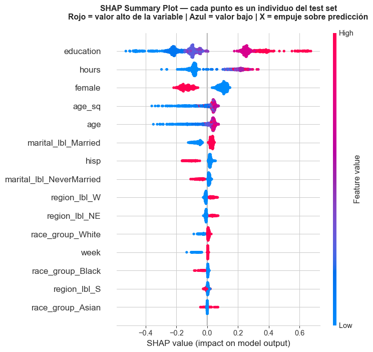

```python
# 7.3.a SHAP summary plot — vista global con dirección de efecto
plt.figure(figsize=(11, 8))
shap.summary_plot(shap_values, X_sample, max_display=15, show=False)
plt.title('SHAP Summary Plot — cada punto es un individuo del test set\n'
          'Rojo = valor alto de la variable | Azul = valor bajo | X = empuje sobre predicción',
          fontweight='bold', pad=20)
plt.tight_layout()
plt.show()
```

**Cómo leer el SHAP summary (¡el plot más informativo del notebook!):**

- Cada **punto es una observación**.
- **Eje Y:** variables ordenadas por importancia.
- **Eje X:** cuánto empuja esa variable la predicción individual (derecha = sube ingreso; izquierda = baja).
- **Color:** rojo = valor alto de la variable; azul = valor bajo.

**Patrones a buscar:**

- `education` rojo a la derecha + azul a la izquierda → relación monótona positiva (educación alta = ingreso alto).
- `female=1` (rojo) a la izquierda → ser mujer empuja la predicción hacia abajo.
- `hours` y `week` rojo a la derecha → trabajar más empuja arriba.

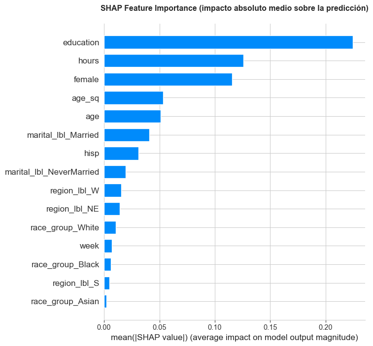

```python
# 7.3.b SHAP bar plot — importancia agregada
plt.figure(figsize=(10, 7))
shap.summary_plot(shap_values, X_sample, plot_type='bar', max_display=15, show=False)
plt.title('SHAP Feature Importance (impacto absoluto medio sobre la predicción)',
          fontweight='bold', pad=20)
plt.tight_layout()
plt.show()
```

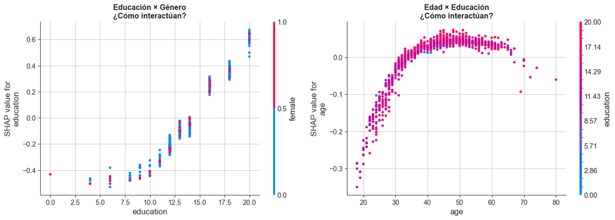

```python
# 7.3.c SHAP dependence plots — interacciones
fig, axes = plt.subplots(1, 2, figsize=(14, 5))

shap.dependence_plot('education', shap_values, X_sample, interaction_index='female',
                     ax=axes[0], show=False)
axes[0].set_title('Educación × Género\n¿Cómo interactúan?', fontweight='bold')

shap.dependence_plot('age', shap_values, X_sample, interaction_index='education',
                     ax=axes[1], show=False)
axes[1].set_title('Edad × Educación\n¿Cómo interactúan?', fontweight='bold')

plt.tight_layout()
plt.show()
```

**SHAP dependence plots** muestran **interacciones** entre variables. Por ejemplo, en el primer panel podemos ver si la educación afecta de forma diferente a hombres y mujeres.

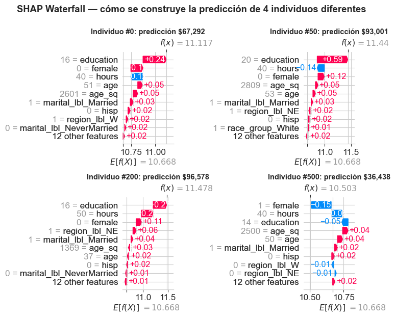

```python
# 7.3.d Explicación local — varios individuos contrastados
indices_to_explain = [0, 50, 200, 500]  # Cuatro individuos distintos

fig, axes = plt.subplots(2, 2, figsize=(16, 11))
axes = axes.flatten()

for ax_idx, idx in enumerate(indices_to_explain):
    individuo = X_sample.iloc[idx]
    pred = rf.predict(individuo.values.reshape(1,-1))[0]

    shap_explanation = shap.Explanation(
        values=shap_values[idx],
        base_values=expected_val,
        data=X_sample.iloc[idx].values,
        feature_names=X_sample.columns.tolist()
    )

    plt.sca(axes[ax_idx])
    shap.plots.waterfall(shap_explanation, max_display=10, show=False)
    axes[ax_idx].set_title(f'Individuo #{idx}: predicción ${np.exp(pred):,.0f}',
                            fontweight='bold', fontsize=11)

plt.suptitle('SHAP Waterfall — cómo se construye la predicción de 4 individuos diferentes',
             fontsize=14, fontweight='bold', y=1.00)
plt.tight_layout()
plt.show()
```

**Para qué sirven los waterfalls en negocio:** son la respuesta "defendible" cuando un colaborador o cliente pregunta *"¿por qué este modelo me asignó este nivel?"*. Cada barra dice exactamente cuánto contribuyó cada variable.

## 8. Traducción a estrategia (Insight → Decisión → Acción → Feedback)

### 8.2 Decisiones (palancas accionables)

**HR / Total Rewards:**

- Auditar brechas salariales controlando por educación, antigüedad y rol.
- Diseñar bandas salariales explícitas para reducir discrecionalidad.
- Programas de patrocinio/mentoría para grupos infrarrepresentados.

**Marketing:**

- Scoring de poder adquisitivo para segmentación premium.

**Política pública:**

- Inversión en educación con retornos altos y consistentes.
- Programas anti-discriminación basados en evidencia.

### 8.3 Acciones (operacionalización)

Aunque es regresión, podemos definir umbrales accionables:

- **Marketing:** "ingreso predicho > $80,000" → segmento premium. El umbral τ se elige por costo de campaña y revenue esperado (la función de costo de la nota IPADE).
- **HR:** "|salario real − salario predicho| / predicho > 15%" → caso a revisar (posible inequidad o top performer infravalorado).

### 8.4 Feedback

- Reentrenar anualmente con CPS-ASEC nuevo.
- Monitorear drift: ¿cambian los drivers con el tiempo?
- A/B test cualquier intervención de HR, midiendo uplift en compensación 2-3 años.

### 8.5 Limitaciones éticas

- **NO es causal.** El coeficiente negativo de `female` no prueba discriminación directa: pueden mediar factores no observados (industria, ocupación, interrupciones de carrera, negociación). Pero **sí justifica investigar**.
- **R² ~0.35-0.41:** 55-65% de la varianza no la explica el modelo. Decisiones individuales no deben basarse solo en él.
- **Datos de 2009:** pueden no reflejar el mercado actual.
- **Fairness:** antes de usarlo para decisiones sobre personas, probar disparate impact y error parity.

## 9. Conclusiones gerenciales (formato IPADE)

### Objetivo

Entender qué factores demográficos y laborales explican las diferencias de ingreso en EE.UU. usando CPS marzo 2009.

### Método

Modelamos `log(earnings)` con 5 enfoques (OLS, Lasso, árbol, Random Forest, Gradient Boosting). Los hiperparámetros de los modelos de árbol se eligieron con búsqueda en validación cruzada (`GridSearchCV` / `RandomizedSearchCV`), usando `Pipeline` para evitar fugas de datos. El desempeño se evaluó con **validación cruzada anidada** —un estimado honesto que no se contamina con la elección de hiperparámetros— y los modelos finales se ajustaron sobre todos los datos para interpretarlos con coeficientes, feature importance, PDP y SHAP.

### Business Impact

- **HR:** detectar inequidades → reducir turnover, mejorar reputación, compliance.
- **Marketing:** scoring de poder adquisitivo para segmentación premium.
- **Política pública:** evidencia para inversión educativa y programas anti-discriminación.

### Next Steps

1. Replicar análisis con datos internos de la organización.
2. Auditar fairness (disparate impact, error parity).
3. Piloto: programa de mentoría dirigido a grupos infravalorados, medir uplift 24-36 meses.
4. Reentrenar y monitorear drift anualmente.
5. Combinar con datos cualitativos para triangular hallazgos.

*Notebook elaborado siguiendo la metodología de la nota técnica IPADE AD 25 eN 06 — "From Machine Learning Models to Strategy" (Herrera, Pensamiento & Rodríguez, 2025).*